# The Great British Tutorial for Data Wrangling

Sydney Whalen

11/16/2025

# Introduction to Data Wrangling

What is data wrangling? Data wrangling is the process of taking data frames and organizing the data in a way suitable to your analytical goals. We’ll be primarily utilizing the *tidyverse* package, which provides us with the functions to rearrange, filter, and create new variables that better allow us to analyze our data. The tidyverse package also provides us with the ggplot2 package which is used to summarize our findings through visuals.

# Data Overview

We’ll be looking over several tools within the tidyverse package to manipulate our *Great British Baking Show* data tables. For those unfamiliar with the *Great British Baking Show*, it is a competition show where contestants participate in three baking challenges per episode and contestants are followed throughout the season and slowly eliminated until the best baker remains.

The data we have imported is two distinct data frames; the challenges data frame and the ratings data frame. The challenges data frame lists the name and win statistics of each contestant per episode, including what the names of their deserts were. The ratings data frame lists the air date of the episode, and the viewership statistics. The goal of manipulating this data is to better analyze the popularity of the *Great British Baking Show* and trends in viewership.

Data courtesy of Alison Hill, accessed through tidytuesday (https://github.com/rfordatascience/tidytuesday/tree/main/data/2022/2022-10-25).

# Preparing to Wrangle

```r
library(tidyverse)
library(readr)
```

We start with loading in our *tidyverse* package, which contains packages *dplr* that we need for organizing and mutating, as well as *ggplot* for creating visuals. We also need readr to properly import our data.

# Wrangling

## Simplifing

```r
ratings=ratings %>%
  select(-starts_with("us"))
```

The rating data frame has many columns of information that aren’t all relevant to our analysis. For the purpose of our analysis, we’re not interested in the variables about release dates in other countries, therefore we can get rid of any columns containing statistics for the US.

**The pipeline operator:** This code starts with using the *pipeline operator* (%>%), a helpful function that allows us to directly refer to column names by specifying the data frame first. The pipeline operator will be helpful later when organizing several steps to manipulate a data frame. ALso note that ratings=ratings overrides the previous version of the ratings data frame with the new version so we can continue to use this version for the remainder of our analysis.

**Selecting:** We are using the *select* function for this pipeline which is used to select columns to keep in the data frame. The minus sign indicates that we want to remove the following columns and keep all others. Within the select function, we’re also using the *starts_with* function, which is a simple way to remove all columns referring to US statistics instead of individually subtracting columns.

## Missing Values

```r
sum(is.na(ratings$viewers_28day))
```

```
## [1] 1
```

```r
sum(is.na(ratings$viewers_7day))
```

```
## [1] 0
```

```r
lm(viewers_28day~viewers_7day, data=ratings)
```

```
##
## Call:
## lm(formula = viewers_28day ~ viewers_7day, data = ratings)
##
## Coefficients:
##  (Intercept)  viewers_7day
##       -3.550         1.166
```

```r
ratings$viewers_28day[which(is.na(ratings$viewers_28day))]<-
  -3.55+1.166*ratings$viewers_7day[which(is.na(ratings$viewers_28day))]
```

We want to eventually be able to summarize the view counts across all episodes, however there are some missing values we want to deal with.

**Is.na and sum functions:** Finding missing values can be achieved by visually scanning the dataset, but for larger data sets, we can check for missingness by using the *is.na* and *sum* functions. Is.na is a function that will check a whole column and will assign a TRUE value if the observation is missing. This logical vector that contains the true and false values is then passed into the sum function, where it adds together the whole column (TRUE=1 and FALSE=0). The output tells us that viewers_28day has one missing value somewhere in the column.

**Regression imputation:** We can handle this missing value by using regression imputation. It’s reasonable to assume the view count at one week (viewers_7day) is a good predictor for the view count at one month (viewers_28day), so we can formulate a linear expression to predict this missing value using what we know about view counts at 7 days (which we calculated has no missing values). This linear relationship is calculated using the *lm()* function, giving us our intercept and slope. The next line of code uses the *which()* function to identify where the missing value is, and simultaneously replaces this missing observation with the predicted value by indexing into the row.

## Summarizing

```r
ratings %>%
  group_by(series) %>%
  summarise(avg_viewers=mean(viewers_28day)) %>%
  slice_max(order_by=avg_viewers, n=3)
```

```
## # A tibble: 3 × 2
##   series avg_viewers
##    <dbl>       <dbl>
## 1      7       13.8
## 2      6       12.3
## 3      9        9.66
```

This pipeline evaluates the most popular seasons of the *Great British Baking Show* and represents the information in a condensed table. This use of the pipeline operator passes down the manipulated version of the data to the next function. This simplifies the notation for writing r code, and is also a good visual for the flow of manipulating a data frame through several steps.

**Grouping:** First, within our ratings data frame we use the *group_by* function to group together all rows that share the same numeric value for season. All observations under series 1 will be grouped together, then series 2, and so forth until all episodes in their respective series are grouped together.

**Summarizing:** In the next line, the *summarise* function is used to find the average amount of views per group (per series). We achieve this by creating a new variable name and assigning it to the *mean* function that finds the average number of views after one month across all episodes in a series, and it will do this calculation for each group.

**Slicing:** The *slice_max* function then formats the table, where order_by specifies that the avg_viewers variable will go in descending order, and n=3 will show only the top 3 most popular seasons (displays the first 3 rows). Note that viewership is in millions.

## Functions and Joins

```r
get_most_pop_episode=function(chosen_season){
    most_pop=ratings %>%
      filter(series==chosen_season) %>%
      left_join(challenges,by= c("series","episode")) %>%
      filter(result=="STAR BAKER" | result=="WINNER") %>%
      arrange(desc(viewers_7day))

    print(paste("In season", chosen_season, "the most watched episode was episode",
                most_pop$episode[1], ".", most_pop$baker[1], "won this episode by impressing the judges with their", most_pop$showstopper[1]))
  }

get_most_pop_episode(2)
```

```
## [1] "In season 2 the most watched episode was episode 8 . Joanne won this episode by impressing the judges with their Mini Victoria SandwichesRaspberry, White Chocolate and Pistachio Mini MeringuesMini Banoffee Pie with Banana Mousse"
```

```r
get_most_pop_episode(6)
```

```
## [1] "In season 6 the most watched episode was episode 10 . Nadiya won this episode by impressing the judges with their My Big Fat British Wedding Cake"
```

Functions can be useful when we want to take a closer look at our data based on a specific variable, but don’t want to rewrite the code every time to accommodate these specifics. This function is created to look at the most watched episode of the inputted season, and also display who won and what they made. The first line inside the function assigns most_pop to the manipulated data frame, this is because we want to save the changes to a new data frame that we can acsess later in the function.

**Filtering:** The filter function is used to scale down the data frame into a more manageable size dependent on the variable we’re interested. The parameter is set so that the ratings data frame is filtered to display only the observations from our chosen series.

**Arranging:** Again we filter our data frame for contestants who have won their respective episodes(STARBAKER denotes a contestant who has won a regular episode, WINNER denotes the contestant who won the finale). After filtering we can use the *arrange* function to order our viewership after one week in descending order using the *desc* function nested inside. This function operates in a similar manner to *slice_max*, but does not require input for the desired number of rows.

The last line in the function outside of the pipeline will print what episode was the most popular, who won, and what they made. This line uses the *paste* function which allows you to use both written text and output from our saved most_pop data frame. We can then index into the first row since we arranged the data frame in a way where the most watched episode would be at the top. The following lines of code show two examples of using this function.

# Visualizing Data

## Working with Time

```r
class(ratings$uk_airdate)
```

```
## [1] "Date"
```

```r
airdate<-strptime(ratings$uk_airdate,"%Y-%m-%d")
ratings$airdate_new<-airdate
class(ratings$airdate_new)
```

```
## [1] "POSIXlt" "POSIXt"
```

```r
air_year<-airdate$year+1900
ratings$year<-air_year
```

We want to make better use of the uk_airdate variable to better visualize the popularity of the show over time. As is, the uk_airdate variable is listed as a date class (which can be manipulated using other packages), but for the sake of working within the tidyverse package we are going to convert uk_airdate into the POSIXlt class (a date time class).

**Converting dates:** Converting the class is achieved by using the strptime() function. It asks that you feed in the date as its presented in the table which is year-month-day format. A quirk about dates in the POSIXT class is that years are represented as integers since the year 1900 (2010 is represented as 110 for example). We can create a variable for year of release by creating an expression that extracts the integer form of the year from airdate and adding 1900, giving us a variable that expresses the release year in integers 2010-2019. Lastly this new variable is then saved into the ratings data frame so we can acsess it later when using ggplot.

## Creating a Bar Chart

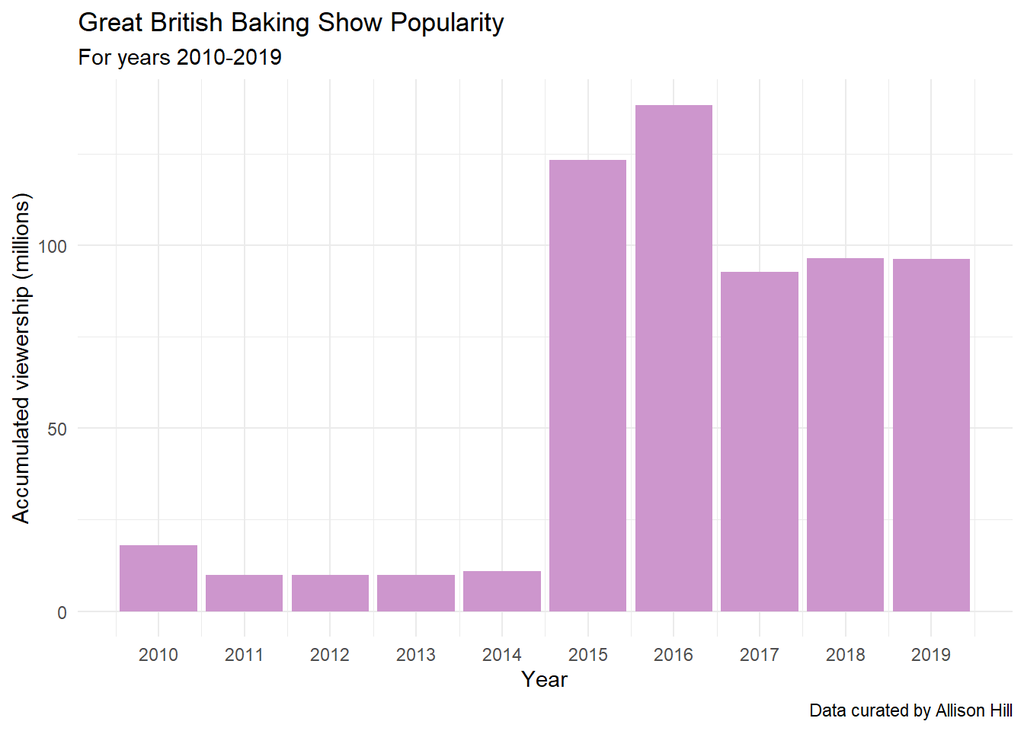

```r
ggplot(ratings, aes(x=year, y=viewers_28day))+
  geom_col(fill="plum3")+
  labs(x= "Year", y="Accumulated viewership (millions)",
       title="Great British Baking Show Popularity", subtitle="For years 2010-2019",
       caption="Data curated by Allison Hill")+
   scale_x_continuous(breaks=2010:2019)+
  theme_minimal()
```

With the creation of the year variable, we are able to visually analyze the popularity of *The Great British Baking Show*. Clearly this graph shows a huge increase in viewership between the years 2014 and 2015 which led to sustained popularity, but why is that? According to the *New Yorker* the show switched from BBC’s secondary channel to their primary channel in 2015, which led to a dramatic increase in viewership (https://www.newyorker.com/magazine/2025/09/01/inside-the-world-of-the-great-british-bake-off). Although this data set does not contain statistics beyond 2019, the show got a second boost in fans once the show started airing on Netflix in 2020 and gained a global audience.